# Tarea2_Nestor_Piedra

Néstor Piedra

2025-06-11

```r
library(readr)
library(dplyr)
library(ggplot2)
library(caret)
library(corrplot)
```

# 📈 Métodos de Regresión

## Tarea 2. Consumo Eléctrico

El consumo eléctrico doméstico es un indicador clave para la planificación de infraestructura energética. Este análisis busca modelar y predecir el comportamiento del consumo activo a partir de variables técnicas registradas minuto a minuto, con el fin de identificar patrones de demanda y generar recomendaciones aplicables a horas pico.

Una incorrecta planeación del consumo eléctrico según las fuentes de energía que se tengan en un país puede desencadenar inconvenientes, como el reciente apagón masivo en la península ibérica, causado presuntamente por un incorrecto análisis del consumo y una dependencia de las energías renovables las cuales no brindan tanta constancia ni consistencia como otros métodos de generación.

### 📊 Carga de los datos

```r
# Carga de los datos y verificación

datos <- read.csv("consumo_electrico_domestico.csv", sep =";", dec = ".", header=TRUE, stringsAsFactors = TRUE)
head(datos)
```

|  | Fecha | Hora | Energia_activa_global | Energia_reactiva_global | Voltaje | Intensidad_global | Submedicion_1 | Submedicion_2 | Submedicion_3 |
| --- | --- | --- | --- | --- | --- | --- | --- | --- | --- |
| 1 | 16/12/2006 | 17:24:00 | 4.216 | 0.418 | 234.84 | 18.4 | 0 | 1 | 17 |
| 2 | 16/12/2006 | 17:25:00 | 5.360 | 0.436 | 233.63 | 23.0 | 0 | 1 | 16 |
| 3 | 16/12/2006 | 17:26:00 | 5.374 | 0.498 | 233.29 | 23.0 | 0 | 2 | 17 |
| 4 | 16/12/2006 | 17:27:00 | 5.388 | 0.502 | 233.74 | 23.0 | 0 | 1 | 17 |
| 5 | 16/12/2006 | 17:28:00 | 3.666 | 0.528 | 235.68 | 15.8 | 0 | 1 | 17 |
| 6 | 16/12/2006 | 17:29:00 | 3.520 | 0.522 | 235.02 | 15.0 | 0 | 2 | 17 |

```r
sum(!is.na(datos))
```

```
## [1] 18495478
```

```r
summary(datos)
```

```
##        Fecha               Hora         Energia_activa_global
##  1/1/2007 :   1440   17:24:00:   1442   Min.   : 0.076
##  1/1/2008 :   1440   17:25:00:   1442   1st Qu.: 0.308
##  1/1/2009 :   1440   17:26:00:   1442   Median : 0.602
##  1/1/2010 :   1440   17:27:00:   1442   Mean   : 1.092
##  1/10/2007:   1440   17:28:00:   1442   3rd Qu.: 1.528
##  1/10/2008:   1440   17:29:00:   1442   Max.   :11.122
##  (Other)  :2066619   (Other) :2066607   NA's   :25979
##  Energia_reactiva_global    Voltaje      Intensidad_global Submedicion_1
##  Min.   :0.000           Min.   :223.2   Min.   : 0.200    Min.   : 0.000
##  1st Qu.:0.048           1st Qu.:239.0   1st Qu.: 1.400    1st Qu.: 0.000
##  Median :0.100           Median :241.0   Median : 2.600    Median : 0.000
##  Mean   :0.124           Mean   :240.8   Mean   : 4.628    Mean   : 1.122
##  3rd Qu.:0.194           3rd Qu.:242.9   3rd Qu.: 6.400    3rd Qu.: 0.000
##  Max.   :1.390           Max.   :254.2   Max.   :48.400    Max.   :88.000
##  NA's   :25979           NA's   :25979   NA's   :25979     NA's   :25979
##  Submedicion_2    Submedicion_3
##  Min.   : 0.000   Min.   : 0.000
##  1st Qu.: 0.000   1st Qu.: 0.000
##  Median : 0.000   Median : 1.000
##  Mean   : 1.299   Mean   : 6.458
##  3rd Qu.: 1.000   3rd Qu.:17.000
##  Max.   :80.000   Max.   :31.000
##  NA's   :25979    NA's   :25979
```

Pueden observarse bastantes NA en el conjunto de datos.Por lo que se realizará una limpieza de los mismos previo a su análisis, así mismo debido a la naturaleza de los datos, para que el modelo tome la menor cantidad de tiempo posible manteniendo información relevante, se limitará el estudio a únicamente un año (2010 por ser el más reciente) para optimizar el rendimiento.

```r
# Convertir fecha y filtrar solo un año
datos$FechaHora <- as.POSIXct(paste(datos$Fecha, datos$Hora), format="%d/%m/%Y %H:%M:%S")
datos$Anno <- format(datos$FechaHora, "%Y")

datos_2010 <- datos %>% filter(Anno == "2010")

# Eliminación de las columnas irrelevantes y NA
datos_modelo <- datos_2010 %>% na.omit() %>% select(-Fecha, -Hora, -FechaHora, -Anno)
```

Con los datos limpios, puede procederse con el modelo de regresión lineal. En este escenario se crea un modelo utilizando las variables disponibles (Excepto Energia_activa_global).

### 📈 Modelo de Regresión Lineal

```r
# Modelo completo
modelo_lm <- lm(Energia_activa_global ~ ., data = datos_modelo)
summary(modelo_lm)
```

```
##
## Call:
## lm(formula = Energia_activa_global ~ ., data = datos_modelo)
##
## Residuals:
##      Min       1Q   Median       3Q      Max
## -0.78453 -0.01345  0.00366  0.01992  0.23018
##
## Coefficients:
##                           Estimate Std. Error t value Pr(>|t|)
## (Intercept)             -1.122e+00  5.453e-03 -205.72   <2e-16 ***
## Energia_reactiva_global -1.875e-01  5.283e-04 -354.89   <2e-16 ***
## Voltaje                  4.654e-03  2.244e-05  207.43   <2e-16 ***
## Intensidad_global        2.388e-01  3.330e-05 7170.54   <2e-16 ***
## Submedicion_1           -1.198e-03  1.391e-05  -86.10   <2e-16 ***
## Submedicion_2           -2.417e-04  1.420e-05  -17.02   <2e-16 ***
## Submedicion_3            2.108e-03  1.110e-05  190.03   <2e-16 ***
## ---
## Signif. codes:  0 '***' 0.001 '**' 0.01 '*' 0.05 '.' 0.1 ' ' 1
##
## Residual standard error: 0.03905 on 457387 degrees of freedom
## Multiple R-squared:  0.9982, Adjusted R-squared:  0.9982
## F-statistic: 4.344e+07 on 6 and 457387 DF,  p-value: < 2.2e-16
```

De acuerdo con el summary de los datos, todas las variables independientes cuentan con suficiente distinción para ser buenas variables predictoras.Por lo que utilizaremos todas las variables para este trabajo.

### 🏋 Entrenamiento de un nuevo modelo de predicción y correlación

```r
tam<-dim(datos_modelo)
n<-tam[1]
muestra <- sample(1:n,floor(n*0.33))

ttesting <- datos_modelo[muestra,]
taprendizaje <- datos_modelo[-muestra,]

modelo <- lm(Energia_activa_global ~ ., data = taprendizaje) # Todas las variables presentaron *** por lo que se utilizan todas

# Predicción
y_predict <- predict(modelo, taprendizaje)
```

Una vez realizada la predicción se genera la correlación:

```r
# Correlación entre predicción y valores reales
correlacion <- cor(y_predict, taprendizaje$Energia_activa_global)
correlacion
```

```
## [1] 0.9991228
```

### ⚡ Energía en 2020

```r
# Carga de los datos y verificación

datos_2020 <- read.csv("consumo_electrico_domestico2020.csv", sep =";", dec = ".", header=TRUE, stringsAsFactors = TRUE)
head(datos_2020)
```

|  | Fecha | Hora | Energia_activa_global | Energia_reactiva_global | Voltaje | Intensidad_global | Submedicion_1 | Submedicion_2 | Submedicion_3 | X | X.1 |
| --- | --- | --- | --- | --- | --- | --- | --- | --- | --- | --- | --- |
| 1 | 1/1/2020 | 15:00:00 | 0,000 | 0.364 | 240.71 | 15.6 | 0 | 0 | 18 | NA | NA |
| 2 | 2/1/2020 | 15:00:00 | 0,000 | 0.256 | 238.81 | 1.4 | 0 | 1 | 17 | NA | NA |
| 3 | 3/1/2020 | 15:00:00 | 0,000 | 0.516 | 237.41 | 2.4 | 0 | 0 | 0 | NA | NA |
| 4 | 4/1/2020 | 15:00:00 | 0,000 | 0.000 | 240.17 | 7.6 | 0 | 0 | 18 | NA | NA |
| 5 | 5/1/2020 | 15:00:00 | 0,000 | 0.000 | 241.09 | 1.2 | 0 | 25 | 0 | NA | NA |
| 6 | 6/1/2020 | 15:00:00 | 0,000 | 0.248 | 241.83 | 1.4 | 0 | 0 | 0 | NA | NA |

```r
sum(!is.na(datos_2020))
```

```
## [1] 3147918
```

```r
summary(datos_2020)
```

```
##        Fecha               Hora         Energia_activa_global
##           :1048209           :1048209        :1048209
##  1/1/2020 :      1   15:00:00:    366   0,000:    366
##  1/10/2020:      1
##  1/11/2020:      1
##  1/12/2020:      1
##  1/2/2020 :      1
##  (Other)  :    361
##  Energia_reactiva_global    Voltaje        Intensidad_global Submedicion_1
##  Min.   :0.0             Min.   :231.0     Min.   : 0.4      Min.   : 0.0
##  1st Qu.:0.0             1st Qu.:239.1     1st Qu.: 1.4      1st Qu.: 0.0
##  Median :0.1             Median :240.7     Median : 2.0      Median : 0.0
##  Mean   :0.1             Mean   :240.4     Mean   : 4.0      Mean   : 0.9
##  3rd Qu.:0.2             3rd Qu.:241.9     3rd Qu.: 6.0      3rd Qu.: 0.0
##  Max.   :0.9             Max.   :246.7     Max.   :27.0      Max.   :38.0
##  NA's   :1048212         NA's   :1048209   NA's   :1048209   NA's   :1048209
##  Submedicion_2     Submedicion_3        X             X.1
##  Min.   : 0.0      Min.   : 0.0      Mode:logical   Mode:logical
##  1st Qu.: 0.0      1st Qu.: 0.0      NA's:1048575   NA's:1048575
##  Median : 0.0      Median : 0.0
##  Mean   : 3.7      Mean   : 6.9
##  3rd Qu.: 1.0      3rd Qu.:17.0
##  Max.   :74.0      Max.   :19.0
##  NA's   :1048209   NA's   :1048209
```

```r
datos_2020$Energia_activa_global <- predict(modelo, newdata = datos_2020)
head(datos_2020)
```

|  | Fecha | Hora | Energia_activa_global | Energia_reactiva_global | Voltaje | Intensidad_global | Submedicion_1 | Submedicion_2 | Submedicion_3 | X | X.1 |
| --- | --- | --- | --- | --- | --- | --- | --- | --- | --- | --- | --- |
| 1 | 1/1/2020 | 15:00:00 | 3.6925283 | 0.364 | 240.71 | 15.6 | 0 | 0 | 18 | NA | NA |
| 2 | 2/1/2020 | 15:00:00 | 0.3116138 | 0.256 | 238.81 | 1.4 | 0 | 1 | 17 | NA | NA |
| 3 | 3/1/2020 | 15:00:00 | 0.4593761 | 0.516 | 237.41 | 2.4 | 0 | 0 | 0 | NA | NA |
| 4 | 4/1/2020 | 15:00:00 | 1.8484367 | 0.000 | 240.17 | 7.6 | 0 | 0 | 18 | NA | NA |
| 5 | 5/1/2020 | 15:00:00 | 0.2809699 | 0.000 | 241.09 | 1.2 | 0 | 25 | 0 | NA | NA |
| 6 | 6/1/2020 | 15:00:00 | 0.2914012 | 0.248 | 241.83 | 1.4 | 0 | 0 | 0 | NA | NA |

```r
datos$DiaSemana <- weekdays(datos$FechaHora)
datos$Hora <- format(datos$FechaHora, "%H:00")

consumo_horario <- datos %>%
  group_by(DiaSemana, Hora) %>%
  summarise(Media = mean(Energia_activa_global, na.rm = TRUE)) %>%
  arrange(desc(Media))

head(consumo_horario, 1)
```

| DiaSemana | Hora | Media |
| --- | --- | --- |
| domingo | 20:00 | 2.15731 |

Con esta información sabemos que el pico de consumo se da el día domingo alrededor de las 8:00 p.m, de manera que puede crearse un modelo para predecir el consumo en horas pico de la red eléctrica.

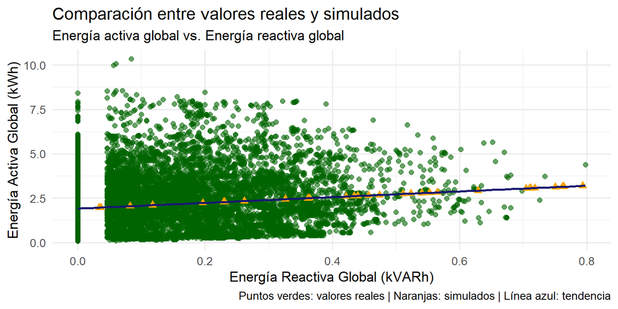

```r
datos_pico <- datos %>%
  filter(weekdays(FechaHora) == "domingo", format(FechaHora, "%H") == "20") %>%
  select(Energia_activa_global, Energia_reactiva_global) %>%
  na.omit()

modelo_pico <- lm(Energia_activa_global ~ Energia_reactiva_global, data = datos_pico)

# Simulacion 30 nuevos valores de x
set.seed(123)
simulacion <- data.frame(Energia_reactiva_global = runif(30,
                                        min = min(datos_pico$Energia_reactiva_global),
                                        max = max(datos_pico$Energia_reactiva_global)))

simulacion$Energia_activa_prediccion <- predict(modelo_pico, newdata = simulacion)

ggplot() +
  geom_point(data = datos_pico, aes(x = Energia_reactiva_global, y = Energia_activa_global), color = "darkgreen", alpha = 0.6, size = 2) +
  geom_point(data = simulacion, aes(x = Energia_reactiva_global, y = Energia_activa_prediccion), color = "orange", shape = 17, size = 2.5) +
  geom_smooth(data = datos_pico, aes(x = Energia_reactiva_global, y = Energia_activa_global), method = "lm", se = FALSE, color = "midnightblue", size = 1) +
  labs(title = "Comparación entre valores reales y simulados",
    subtitle = "Energía activa global vs. Energía reactiva global",
    x = "Energía Reactiva Global (kVARh)",
    y = "Energía Activa Global (kWh)",
    caption = "Puntos verdes: valores reales | Naranjas: simulados | Línea azul: tendencia"
  ) +
  theme_minimal(base_size = 13)
```

### 📌 Conclusiones

- El modelo logra predecir el consumo eléctrico con alta precisión (correlación 0.999).
- El mayor consumo se presenta los domingos a las 8:00 p.m., lo cual indica una posible saturación de la red en ese horario.
- Este tipo de modelo podría ayudar a mejorar la gestión de la demanda eléctrica en zonas residenciales.

Como mejora futura, podrían incorporarse todos los años al análisis para un mejor modelo de predicción.